# Recovery Overview - Elephant Plus

2024-10-03

This document walks through the Reorienting to Recovery’s Recovery Definition and evaluates how the Elephant Plus Balanced Scenario Performs. It provides summary statistics and visualizations to evaluate recovery according to defined thresholds recovery metrics (Threshold Recovery Metrics table below) and to explore results associated with non thereshold biological metrics (Additional Biological Metrics table below).

## Review Indicator Populations

The Reorienting to Recovery selected a few indicator populations as a starting point for evaluating recovery of scenarios. For the Fall Run Chinook model, we selected:

- Upper Sacramento River
- American River (?)
- Stanislaus River
- Tuolumne River

Indicator rivers must meet all recovery metrics in last 15 years of the simulation.

Secondarily, all independent populations must meet recovery in at least 5 years and the percentage of ind populations that meet recovery objects must be above 80% in last 15 years.

## Review Biological Recovery Metrics

### Threshold Recovery Metrics

The table below summarizes Recovery Metrics that have associated Recovery Thresholds. For each of these metrics, scenarios are evaluated to see what percentage or tributaries or years they achieve the recovery target for each scenario.

| **Value** | **Performancemeasure** | **Description** | **Target/Recovery Threshold** |
| --- | --- | --- | --- |
| 1: Salmonid abundance | 1: Adult abundance | Represents an interest in increasing salmonid abundance across the Central Valley. Can be estimated with models as annual number of adult spawning salmonids in each tributary and ocean, tracked for 20… | 500 or more spawners |
| 2: Salmonid productivity | 2.1: Cohort Replacement | Represents an interest in having growing or stable salmonid populations. CRR can be estimated with models as the adult natural origin return ratio in each tributary, tracked for 20 years. CRR is calcu… | Mean CRR > 1 |
| 2: Salmonid productivity | 2.2: Population growth rate | Represents an alternative way to capture growing or stable salmonid populations. Can be estimated with models as average trend in population growth over a 20-year period. | Mean Growth Rate > 1 |
| 4: Salmonid genetic diversity | 4: pHOS | Represents an interest in preserving genetic diversity of natural populations and minimizing potential negative demographic effects from hatchery origin fish. Salmonid models are currently being modif… | pHOS < 5% |

### Additional Biological Recovery Metrics

The table below provides additional recovery metrics to help balance and refine scenarios. This set of metrics does not have clear threshold values that indicate recovery but instead provides additional context to help select more balanced scenarios.

| **Value** | **Performance measure** | **Description** |
| --- | --- | --- |
| 3: Salmonid spatial structure | 3.1: Independent populations | Represents an interest in increasing and maintaining the distribution of salmonids across historically occupied watersheds. Watershed-specific abundance estimates from models can be used to calculate … |
| 3: Salmonid spatial structure | 3.2: % of potential independent populations | Represents an alternative way to capture the distribution of salmonid, calculated as the % of potential independent viable populations in each diversity group per ESU/run. |
| 3: Salmonid spatial structure | 3.3: Dependent populations | *Represents an interest in increasing and maintaining the distribution of salmonids across historically occupied watersheds. Watershed-specific CV Salmon Recovery abundance estimates from models can b… |
| 5: Salmonid life history diversity | 5.1: Age distribution of spawning adults | Represents an interest in preserving life history diversity (age of spawners) in natural populations. Salmonid models can be used to estimate the minimum % of each age class of adults and check if tar… |
| 5: Salmonid life history diversity | 5.2: Size distribution of juveniles | Represents an interest in preserving life history diversity (size distribution of juveniles) in natural populations. Salmonid models can be used to estimate the variation in juvenile abundance of each… |
| 5: Salmonid life history diversity | 5.3: Size and timing of juveniles at ocean entry | Represents an interest in preserving life history diversity (size and timing of juveniles at ocean entry) in natural populations. Size distribution and timing of juveniles at ocean entry is summarized… |
| 5: Salmonid life history diversity | 5.4: Habitat diversity | Represents an interest in preserving habitat diversity that facilitates life history diversity in natural populations. Could be estimated as the amount and relative % of available habitat of different… |
| 6: Abundance, productivity, and distribution at levels that support ecosystem health | 6: Ecosystem health | Represents an interest in maintaining resilient and functioning ecosystems due to adequate salmonid abundance. Could be captured with a proxy metric of ratio of spawner abundance to habitat (marine de… |
| 7: Biological recovery objectives met by certain time | 7: Time to biological recovery | Represents an interest to recover salmonids quickly. Can be estimated by salmon models as the # of years until recovery objectives are met. See Phase 1 report for a list of recovery objectives. |

## Review Elephant Plus Scenario

The Elephant Plus scenario includes efforts in each of the 4 knobs that we can turn in the R2R process: Habitat, Hydrology, Harvest (oceans & rivers) and Hatcheries. The table below summarizes the Elephant Plus scenario in comparison to the Baseline scenario.

[output not shown]

## Run Elephant Plus Scenario

The following code block runs the Elephant Plus scenario.

```r
# BASELINE --
new_params <- fallRunDSM::r_to_r_baseline_params
new_params$movement_hypo_weights <- c(1, rep(0, 7))
new_params$san_joaquin_flows <- matrix(0, nrow = 12, ncol = 21,
                                       dimnames = list(month.abb, 1980:2000))

# seed
r2r_seeds_elephant_plus <- fallRunDSM::fall_run_model(mode = "seed",
                                           seeds = fallRunDSM::adult_seeds,
                                        ..params =  new_params, # seed with baseline, then elephant
                                        delta_surv_inflation = FALSE)

# run model
r2r_model_results_elephant_plus <- fallRunDSM::fall_run_model(mode = "simulate",
                                                         scenario = "elephant_plus",
                                                ..params =  new_params,
                                                seeds = r2r_seeds_elephant_plus,
                                                delta_surv_inflation = TRUE)
```

## Results

Model results should be evaluated relative to the Baseline model. The following plots show the % difference from baseline results for the Elephant Plus scenario. You can look at the tab to the right to see the total spawner trends of the Elephant Plus Scenario in comparison to the Baseline Scenario. *(Make add a percent difference table in here too) - Think through the best way to present these. Also add a percent difference bar plot)*

### % Difference from Baseline (all watersheds)

[interactive chart not shown]

### % Difference from Baseline (all watersheds)

[interactive chart not shown]

### Spawners Plot

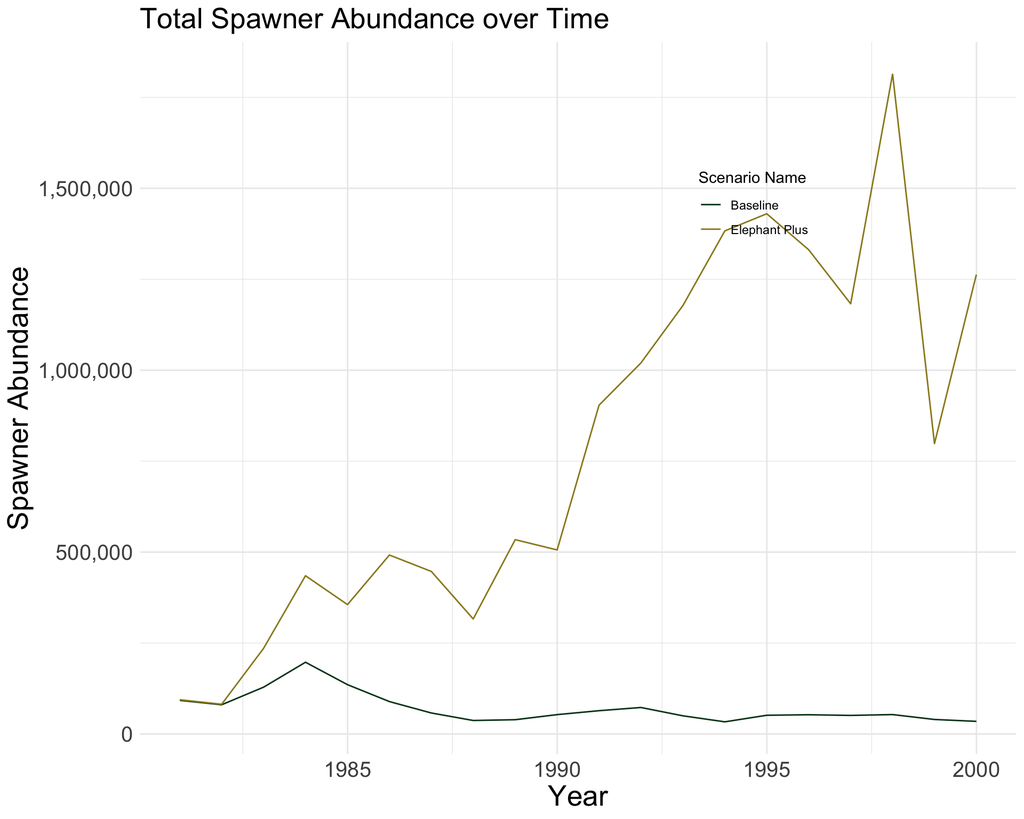

## Threshold Biological Performance Metrics

The two tabs below show plots that describe if a tributary meets the recovery objective.

*(TODO: maybe color indicator pops differently)*

### Abundance and Genetic Diversity

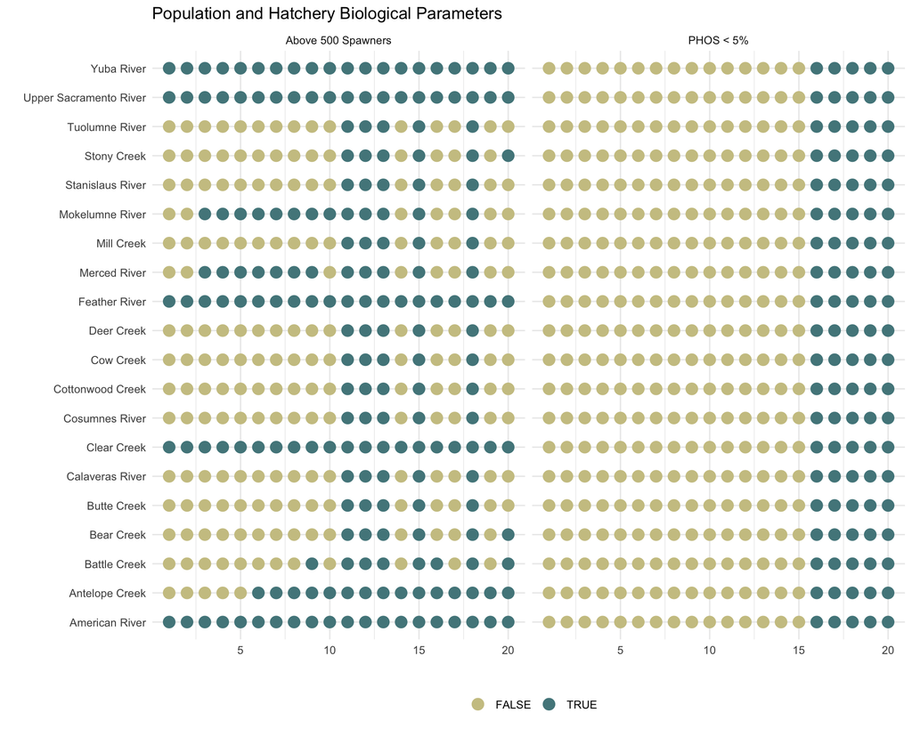

### Productivity Metrics

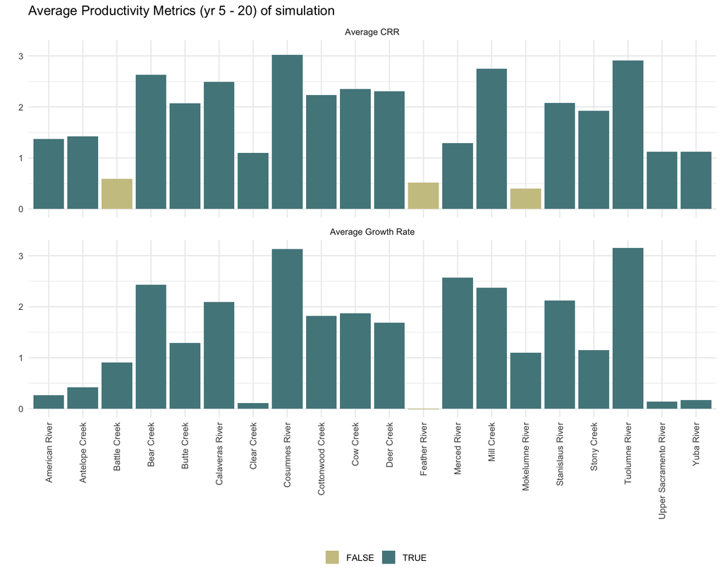

## Additional Biological Performance Metics

### Spatial Structure

[output not shown]

```
## # A tibble: 4 × 1
##   location
##   <chr>
## 1 Battle Creek
## 2 Bear Creek
## 3 Cow Creek
## 4 Upper Sacramento River
```

[interactive chart not shown]